# Séries Temporais Hierárquicas e Agrupadas

## Motivação

### Case 1:

Você começou a trabalhar no ministério de turismo e relações exteriores da Austrália e sua primeira tarefa é fazer a previsão do número de viajantes que chegarão ao País no próximo trimestre (mas também querem saber a previsão por estado e região, se for possível).

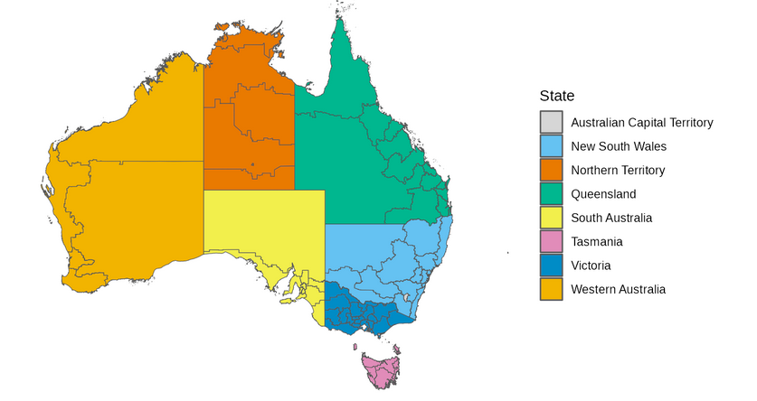

Australia dividida por estados

O conjunto de dados a ser análisado já está disponível na empresa e é carregado no **R** com o nome `tourism`

```r
library(fpp3)
library(patchwork)
glimpse(tourism)
```

```
Rows: 24,320
Columns: 5
Key: Region, State, Purpose [304]
$ Quarter <qtr> 1998 Q1, 1998 Q2, 1998 Q3, 1998 Q4, 19…
$ Region  <chr> "Adelaide", "Adelaide", "Adelaide", "A…
$ State   <chr> "South Australia", "South Australia", …
$ Purpose <chr> "Business", "Business", "Business", "B…
$ Trips   <dbl> 135.0777, 109.9873, 166.0347, 127.1605…
```

O ministério não considera importante separar o motivo da viagen. Assim você precisa agregar os dados por região e estado.

```r
tourism_hts <- tourism |>
  aggregate_key(State / Region, Trips = sum(Trips))
tourism_hts
```

| Quarter | State | Region | Trips |
| --- | --- | --- | --- |
| 1998 Q1 |  |  | 23182.197269 |
| 1998 Q2 |  |  | 20323.380067 |
| 1998 Q3 |  |  | 19826.640511 |
| 1998 Q4 |  |  | 20830.129891 |
| 1999 Q1 |  |  | 22087.353380 |
| 1999 Q2 |  |  | 21458.373285 |
| 1999 Q3 |  |  | 19914.192508 |
| 1999 Q4 |  |  | 20027.925640 |
| 2000 Q1 |  |  | 22339.294779 |
| 2000 Q2 |  |  | 19941.063482 |

[output cut: 990 more lines]

> Observação: a função `aggregate_key()` tem uma nomenclatura de `pai/filho`.

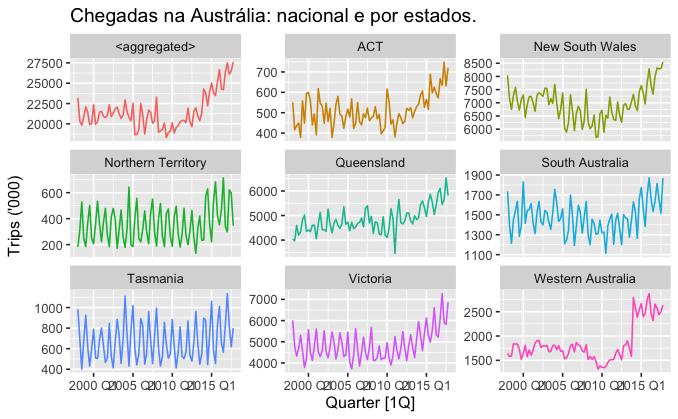

```r
tourism_hts |>
  filter(is_aggregated(Region)) |>
  autoplot(Trips) +
  labs(y = "Trips ('000)",
       title = "Chegadas na Austrália: nacional e por estados.") +
  facet_wrap(vars(State), scales = "free_y", ncol = 3) +
  theme(legend.position = "none")
```

Por curiosidade, você resolve ver qual é o comportamento das regiões dentro de cada estado.

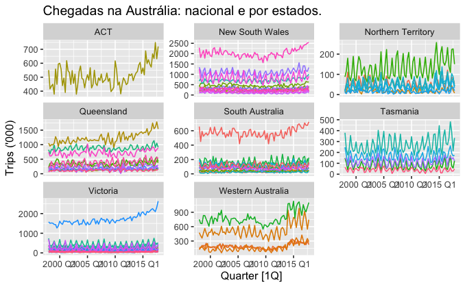

```r
tourism_hts |>
  filter(!is_aggregated(Region)) |>
  autoplot(Trips) +
  labs(y = "Trips ('000)",
       title = "Chegadas na Austrália: nacional e por estados.") +
  facet_wrap(vars(State), scales = "free_y", ncol = 3) +
  theme(legend.position = "none")
```

Este tipo de dados de séries temporais são conhecidos como séries temporis hierárquicas, pois possuem uma hierarquia.

Se $y_t$ denotar o número de chegadas na Austrália no tempo $t$, e $y_{j,t}$ denotar o número de chegadas para o estados/região da Austrália no tempo $t$. Teriamos que

$$y_t = \underbrace{y_{AA, t} + y_{AB, t}
+ y_{AC, t}}_{y_{A, t}} + \underbrace{y_{BA, t} + y_{BB, t}}_{y_{B,
t}}$$

### Case 2:

Você começa a trabalhar no judiciário da Austrália e sua primeira tarefa é fazer uma previsão do total (mas também, se for possível, por sexo, situação legal, estado) de presos para o próximo trimestre. Os dados estão disponível no seguinte [link](https://OTexts.com/fpp3/extrafiles/prison_population.csv)

```r
prison <- readr::read_csv("https://OTexts.com/fpp3/extrafiles/prison_population.csv")
glimpse(prison)
```

```
Rows: 3,072
Columns: 6
$ Date       <date> 2005-03-01, 2005-03-01, 2005-03-01…
$ State      <chr> "ACT", "ACT", "ACT", "ACT", "ACT", …
$ Gender     <chr> "Female", "Female", "Female", "Fema…
$ Legal      <chr> "Remanded", "Remanded", "Sentenced"…
$ Indigenous <chr> "ATSI", "Non-ATSI", "ATSI", "Non-AT…
$ Count      <dbl> 0, 2, 0, 5, 7, 58, 5, 101, 51, 131,…
```

```r
prison$Date[c(1, 2, 85, 86, 469, 470)]
```

```
[1] "2005-03-01" "2005-03-01" "2005-06-01" "2005-06-01"
[5] "2006-12-01" "2006-12-01"
```

```r
prison <- prison |>
  mutate(Quarter = yearquarter(Date)) |>
  select(-Date)  |>
  as_tsibble(key = c(Gender, Legal, State, Indigenous),
             index = Quarter) |>
  relocate(Quarter)
glimpse(prison)
```

```
Rows: 3,072
Columns: 6
Key: State, Gender, Legal, Indigenous [64]
$ Quarter    <qtr> 2005 Q1, 2005 Q2, 2005 Q3, 2005 Q4,…
$ State      <chr> "ACT", "ACT", "ACT", "ACT", "ACT", …
$ Gender     <chr> "Female", "Female", "Female", "Fema…
$ Legal      <chr> "Remanded", "Remanded", "Remanded",…
$ Indigenous <chr> "ATSI", "ATSI", "ATSI", "ATSI", "AT…
$ Count      <dbl> 0, 1, 0, 0, 1, 1, 1, 0, 0, 1, 1, 1,…
```

Veja que, neste caso, as séries não são aninhadas (poderiamos dividir a série por Genero, por estado, por situação legal). **Não existe uma única forma de criar as hierarquias.**

```r
prison_gts <- prison |>
  aggregate_key(Gender * Legal * State, Count = sum(Count)/1e3)
glimpse(prison_gts)
```

```
Rows: 3,888
Columns: 5
Key: Gender, Legal, State [81]
$ Quarter <qtr> 2005 Q1, 2005 Q2, 2005 Q3, 2005 Q4, 20…
$ Gender  <chr*> <aggregated>, <aggregated>, <aggregat…
$ Legal   <chr*> <aggregated>, <aggregated>, <aggregat…
$ State   <chr*> <aggregated>, <aggregated>, <aggregat…
$ Count   <dbl> 24.296, 24.643, 24.511, 24.393, 24.524…
```

> Observação: a sintaxe `Gender * Legal * State` indica que não existe uma hierarquia mas que são níveis cruzados.

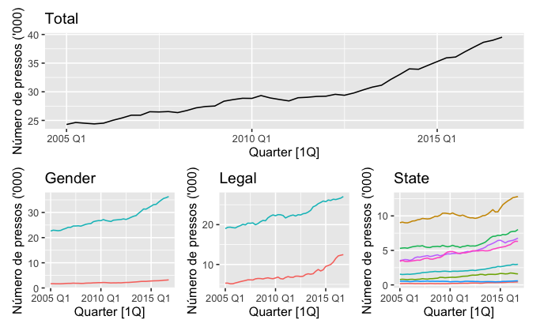

```r
p1 <- prison_gts |>
  filter(!is_aggregated(Gender), is_aggregated(Legal),
         is_aggregated(State)) |>
  autoplot(Count) +
  theme(legend.position = "none") +
  labs(y = "Número de pressos ('000)") + ggtitle("Gender")
p2 <- prison_gts |>
  filter(is_aggregated(Gender), !is_aggregated(Legal),
         is_aggregated(State)) |>
  autoplot(Count) +
  theme(legend.position = "none") +
  labs(y = "Número de pressos ('000)") + ggtitle("Legal")
p3 <- prison_gts |>
  filter(is_aggregated(Gender), is_aggregated(Legal),
         !is_aggregated(State)) |>
  autoplot(Count) +
  theme(legend.position = "none") +
  labs(y = "Número de pressos ('000)") + ggtitle("State")
p4 <- prison_gts |>
  filter(is_aggregated(Gender), is_aggregated(Legal),
         is_aggregated(State)) |>
  autoplot(Count) +
  theme(legend.position = "none") +
  labs(y = "Número de pressos ('000)") + ggtitle("Total")
p4 / (p1 + p2 + p3)
```

Este tipo de dados de séries temporais são conhecidos como séries temporais agrupadas (não podem ser desagregadas de uma única forma).

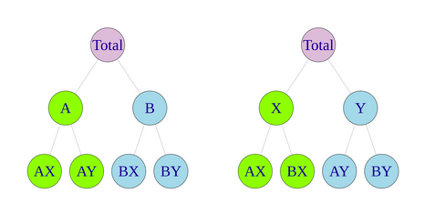

Utilizando a mesma notação definida anteriormente,

$$y_t = y_{A, t} + y_{B, t} \quad ou \quad
y_t = y_{X, t} + y_{Y, t}$$

$$y_t = \underbrace{y_{AX, t} + y_{AY,
t}}_{y_{A,t}} + \underbrace{y_{BX, t} + y_{BY, t}}_{y_{B,t}}\quad ou
\quad y_t = \underbrace{y_{AX, t} + y_{BX, t}}_{y_{X,t}}+
\underbrace{y_{AY, t} + y_{BY, t}}_{y_{Y, t}}$$

> É possível também que seja possível desagregar se forma mista (algumas níveis são desagregados hierarquicamente mas existem outros que são cruzados)

```r
tourism_full <- tourism |>
  aggregate_key((State/Region) * Purpose, Trips = sum(Trips))
glimpse(tourism_full)
```

```
Rows: 34,000
Columns: 5
Key: State, Purpose, Region [425]
$ Quarter <qtr> 1998 Q1, 1998 Q2, 1998 Q3, 1998 Q4, 19…
$ State   <chr*> <aggregated>, <aggregated>, <aggregat…
$ Purpose <chr*> <aggregated>, <aggregated>, <aggregat…
$ Region  <chr*> <aggregated>, <aggregated>, <aggregat…
$ Trips   <dbl> 23182.20, 20323.38, 19826.64, 20830.13…
```

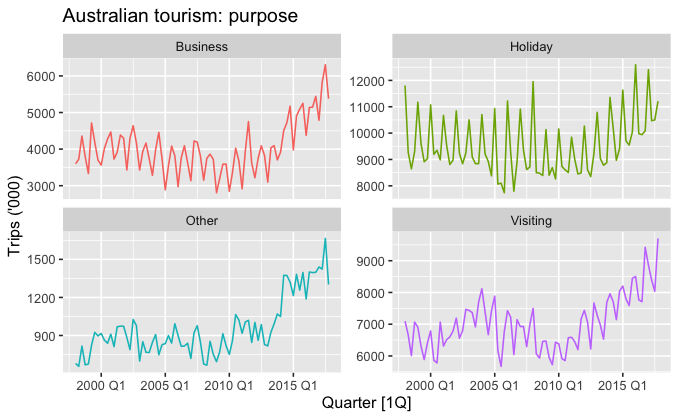

```r
tourism_full |>
  filter(!is_aggregated(Purpose), is_aggregated(State)) |>
  autoplot(Trips) +
  labs(y = "Trips ('000)",
       title = "Australian tourism: purpose") +
  facet_wrap(vars(Purpose), scales = "free_y", ncol = 2) +
  theme(legend.position = "none")
```

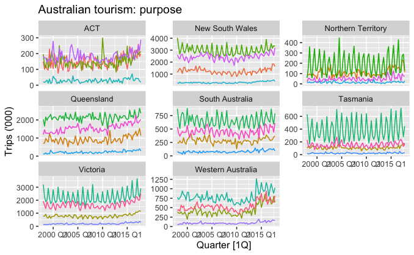

```r
tourism_full |>
  filter(!is_aggregated(Purpose), !is_aggregated(State), is_aggregated(Region)) |>
  autoplot(Trips) +
  labs(y = "Trips ('000)",
       title = "Australian tourism: purpose") +
  facet_wrap(vars(State), scales = "free_y", ncol = 3) +
  theme(legend.position = "none")
```

**Como podemos lidar com esse tipo de dados de séries temporais?**

## Abordagens de nível único

Isto implica selecionar um nível de agregação e gerar previsões para cada uma das séries nesse nível. Estas previsões são agregados para níveis mais altos, ou desagregados para níveis mais baixos (desta forma obtemos previsões coerentes para o resto da estrutura).

Este tipo de modelagem pode ser feito de cima para abaixo (top-down)ou de baixo para cima (bottom-up).

### De baixo pra cima

Fazer previsão para cada uma das séries no nível mais baixo e depois ir somando as previsões para os níveis subsequantes até chegar ao nível mais alto (total).

Pense na série de turismo. Vamos supor que previsões por regiões não são interessantes e apenas utilizar estados.

```r
tourism_states <- tourism |>
  aggregate_key(State, Trips = sum(Trips))
glimpse(tourism_states)
```

```
Rows: 720
Columns: 3
Key: State [9]
$ Quarter <qtr> 1998 Q1, 1998 Q2, 1998 Q3, 1998 Q4, 19…
$ State   <chr*> <aggregated>, <aggregated>, <aggregat…
$ Trips   <dbl> 23182.20, 20323.38, 19826.64, 20830.13…
```

```r
fcasts_state <- tourism_states |>
  filter(!is_aggregated(State)) |>
  model(ets = ETS(Trips)) |>
  forecast(h = 5)
fcasts_state
```

| State | .model | Quarter | Trips | .mean |
| --- | --- | --- | --- | --- |
| ACT | ets | 2018 Q1 | N(701, 7651) | 700.6943 |
| ACT | ets | 2018 Q2 | N(717, 8032) | 717.2949 |
| ACT | ets | 2018 Q3 | N(734, 8440) | 733.8954 |
| ACT | ets | 2018 Q4 | N(750, 8882) | 750.4960 |
| ACT | ets | 2019 Q1 | N(767, 9368) | 767.0965 |
| New South Wales | ets | 2018 Q1 | N(8886, 96984) | 8885.5451 |
| New South Wales | ets | 2018 Q2 | N(8311, 122362) | 8310.7663 |
| New South Wales | ets | 2018 Q3 | N(8110, 147740) | 8109.7451 |
| New South Wales | ets | 2018 Q4 | N(8494, 173128) | 8493.8630 |
| New South Wales | ets | 2019 Q1 | N(8886, 2e+05) | 8885.5451 |

[output cut: 30 more lines]

```r
fcasts_national <- fcasts_state |>
  summarise(value = sum(Trips), .mean = mean(value))
fcasts_national
```

| Quarter | value | .mean |
| --- | --- | --- |
| 2018 Q1 | N(28925, 480068) | 28924.60 |
| 2018 Q2 | N(26929, 509928) | 26928.97 |
| 2018 Q3 | N(26267, 564670) | 26266.73 |
| 2018 Q4 | N(27166, 7e+05) | 27165.55 |
| 2019 Q1 | N(28991, 935854) | 28991.01 |

Em geral, se tivermos vários níveis, podemos utilizar

```r
tourism_states |>
  model(ets = ETS(Trips)) |>
  reconcile(bu = bottom_up(ets)) |>
  forecast(h = 5)
```

| State | .model | Quarter | Trips | .mean |
| --- | --- | --- | --- | --- |
| ACT | ets | 2018 Q1 | N(701, 7651) | 700.6943 |
| ACT | ets | 2018 Q2 | N(717, 8032) | 717.2949 |
| ACT | ets | 2018 Q3 | N(734, 8440) | 733.8954 |
| ACT | ets | 2018 Q4 | N(750, 8882) | 750.4960 |
| ACT | ets | 2019 Q1 | N(767, 9368) | 767.0965 |
| ACT | bu | 2018 Q1 | N(701, 7651) | 700.6943 |
| ACT | bu | 2018 Q2 | N(717, 8032) | 717.2949 |
| ACT | bu | 2018 Q3 | N(734, 8440) | 733.8954 |
| ACT | bu | 2018 Q4 | N(750, 8882) | 750.4960 |
| ACT | bu | 2019 Q1 | N(767, 9368) | 767.0965 |

[output cut: 80 more lines]

> A vantagem desta abordagem é que estamos utilizando o nível mais baixo da séries (ou seja, nenhuma informação é perdida pela agregação). Por outro lado, esta abordagem ignora a relação entre as séries e se o nível mais baixo da série for *altamente desagregado* pode ser dificil de modelar (pouco sinal, muito ruido).

### De cima pra baixo

Consiste em fazer a previsão para o nível mais alto (o total) e depois desagregar a série para os níveis mais baixos.

Sejam $p_1, \cdots, p_m$ as proporções de desagragação nos níveis mais baixos, ou seja, como a previsão do total será desagregada nos níveis mais baixos. Por exemplo, na seguinte hierarquia

$$y_{AA, t} = p_{AA}y_t, \quad y_{AB, t} =
p_{AB}y_t, \quad y_{AC, t} = p_{AC}y_t, \quad y_{BA, t} = p_{BA}y_t,
\quad y_{BB, t} = p_{BB}y_t.$$

Uma vez que as previsões dos níveis mais baixos são obtidas, basta agregar elas para obter previsões coerentes nos níveis intermediários.

**Como calcular as proporções?**

#### Média das proporções históricas

$$p_j = \dfrac{1}{T} \displaystyle \sum_{t
= 1}^T \dfrac{y_{j,t}}{y_t}$$

#### Proporção da média histórica

$$p_j = \dfrac{\displaystyle \sum_{t =
1}^T \dfrac{y_{j,t}}{T}}{\displaystyle \sum_{t = 1}^T
\dfrac{y_t}{T}}$$

Ambos os métodos consideram que a proporção de desagregação é constante ao longo do tempo, o que em alguns casos pode estar longe da realidade. Para contornar este problema, a proposta de [Athanasopoulos et al. 2009](https://www.sciencedirect.com/science/article/abs/pii/S0169207008000691) pode ser utilizada.

Para ilustrar como o método funciona, pense em uma série com apenas um nível de hierarquia:

1. Faça a previsão $h$ passos à frente para cada umas das séries (estás previsões serão apenas utilizadas para calcular a proporção de desagregação).
2. Calculamos a proporção de cada previsão $h$ passos à frente no nível inferior w.r.t o agregado de todas as previsões nesse nível.
3. Essas proporções serão chamadas de proporções de previsão e são as que serão utilizadas para desagregar a série no nível mais baixo.

Em geral, para uma série com $K$-níveis hierárquicos, obtemos as proporções de previsão como
$$p_j =
\displaystyle \prod_{l = 1}^{K}
\dfrac{\hat{y}_{j,h}^{(l)}}{\hat{S}_{j,h}^{(l+1)}},$$
em que $\hat{y}_{j,h}^{(l)}$ é a previsão $h$ passos à frente das séries no nível $l$ e $\hat{S}_{j, h}^{(l+1)}$ é a previsão agregada (do nó $j$) $h$ passos à frente da série no nível superior ($l + 1$).

> **A vantagem do método de “cima pra baixo” é que produz boas previsões para os níveis agregados, principalmente quando temos poucas observações nos níveis mais baixos. A desvantagem é que perdemos as particularidades das séries individuais nos níveis mais baixos e produz previsões coeherentes viesadas [(Hyndman et al. 2011)](https://www.sciencedirect.com/science/article/pii/S0167947311000971).**

Todos esses métodos estão implementados no R:

| Método | R |
| --- | --- |
| Média das proporções históricias | `top_down(method = "average_proportions")` |
| Proporção das médias históricias | `top_down(method = "proportion_averages")` |
| Proporção das previsões | `top_down(method = "forecast_proportions")` |

## Forecast Reconciliation.

*Forecast reconciliation* é o processo de ajustar as previsões para que elas sejam coerentes, ou seja, que a previsão dos níveis agregados seja igual à soma das previsões dos níveis desagregados.

Pense nas equações que definem as séries hierárquicas

$$y_t = \underbrace{y_{AA, t} + y_{AB, t}
+ y_{AC, t}}_{y_{A, t}} + \underbrace{y_{BA, t} + y_{BB, t}}_{y_{B,
t}}.$$

Podemos reescrever todas as relações através de uma forma matricial:

$$\underbrace{\begin{bmatrix}
y_t \\
y_{A,t}\\
y_{B,t} \\
y_{AA, t} \\
y_{AB, t} \\
y_{AC, t} \\
y_{BA, t} \\
y_{BB, t}
\end{bmatrix}}_{\textbf{y}_t} = \underbrace{\begin{bmatrix}
1 & 1 & 1 & 1 & 1 \\
1 & 1 & 1 & 0 & 0 \\
0 & 0 & 0 & 1 & 1 \\
1 & 0 & 0 & 0 & 0 \\
0 & 1 & 0 & 0 & 0 \\
0 & 0 & 0 & 1 & 0 \\
0 & 0 & 0 & 0 & 1
\end{bmatrix}}_{\textbf{S}} \times \underbrace{\begin{bmatrix}
y_{AA, t} \\
y_{AB, t} \\
y_{AC, t} \\
y_{BA, t} \\
y_{BB, t}
\end{bmatrix}}_{\textbf{b}_t}$$

De forma semelhante, podemos reescrever as equações que definem as séries agrupadas como

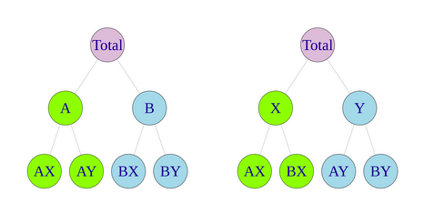

$$\underbrace{\begin{bmatrix}
y_t \\
y_{A,t}\\
y_{B,t} \\
y_{X,t}\\
y_{Y,t} \\
y_{AX, t} \\
y_{AY, t} \\
y_{AC, t} \\
y_{BX, t} \\
y_{BY, t}
\end{bmatrix}}_{\textbf{y}_t} = \underbrace{\begin{bmatrix}
1 & 1 & 1 & 1 \\
1 & 1 & 0 & 0 \\
0 & 0 & 1 & 1 \\
1 & 0 & 1 & 0 \\
0 & 1 & 0 & 1 \\
1 & 0 & 0 & 0\\
0 & 1 & 0 & 0\\
0 & 0 & 1 & 0\\
0 & 0 & 0 & 1\\
\end{bmatrix}}_{\textbf{S}} \times \underbrace{\begin{bmatrix}
y_{AX, t} \\
y_{AY, t} \\
y_{BX, t} \\
y_{BY, t}
\end{bmatrix}}_{\textbf{b}_t}$$

Esta notação matricial permite que utilizemos uma única notação para séries hierárquicas ou agrupadas.

Suponha que você faz a previsão para todas as séries ignorando as restrições de agregação (ou seja, as previsões não são coerentes).

Então, todas as previsões coerentes podem ser obtidas através de

$$\tilde{\textbf{y}}_{t+h} = \textbf{S}
\textbf{G} \hat{\textbf{y}}_{t+h},$$

- $\textbf{G}:$ mapeia as previsões no nível inferior
- $\textbf{S}:$ faz a agregação nos próximos níveis para produzir previsões coerentes.

A matriz $\textbf{G}$ deve ser escolhida de forma apropriada. Por exemplo, se a abordagem for de baixo pra cima, definimos, para o caso do nosso exemplo,

$$\textbf{G} = \begin{bmatrix}
0 & 0 & 0 & 1 & 0 & 0 & 0 & 0 \\
0 & 0 & 0 & 0 & 1 & 0 & 0 & 0 \\
0 & 0 & 0 & 0 & 0 & 1 & 0 & 0 \\
0 & 0 & 0 & 0 & 0 & 0 & 1 & 0 \\
0 & 0 & 0 & 0 & 0 & 0 & 0 & 1 \\
\end{bmatrix}$$

Se a abordagem for de cima pra baixo,
$$\textbf{G} = \begin{bmatrix}
p_1 & 0 & 0 & 0 & 0 & 0 & 0 & 0 \\
p_2 & 0 & 0 & 0 & 0 & 0 & 0 & 0 \\
p_3 & 0 & 0 & 0 & 0 & 0 & 0 & 0 \\
p_4 & 0 & 0 & 0 & 0 & 0 & 0 & 0 \\
p_5 & 0 & 0 & 0 & 0 & 0 & 0 & 0 \\
\end{bmatrix}$$

Assim, pre-multiplicando as previsões base por $\textbf{SG}$, temos um conjunto de previsões coerentes.

> Até aqui, os métodos descritos apenas consideram previsões de um único nível para depois agregar ou desagregar e obter as previsões para todos os outros níveis. Contudo, em geral, poderiamos utilizar outras matrizes $\textbf{G}$ e então combinar $\textbf{SG}$ para obter todas as previsões coerentes. De fato, podemos obter uma matriz $\textbf{G}$ ótima para termos previsões mais acuradas.

## O método MinT (Minimum Trace)

[Wickramasuriya et al. 2019](https://www.tandfonline.com/doi/abs/10.1080/01621459.2018.1448825?journalCode=uasa20) propuseram um método para obter a matriz $\textbf{G}$ de forma que a variância das previsões coerentes seja mínima.

Suponha que para obter previsões coerentes utilizamos
$$\tilde{\textbf{y}}_{t+h} = \textbf{SG}
\hat{\textbf{y}}_{t+h}.$$

1. Gostariamos que as previsões sejam não viesadas. Se as previsões base são não viesadas, então $\tilde{\textbf{y}}_{t+h}$ serão não viesadas se $\textbf{SGS} = \textbf{S}$ (nas abordagem de cima pra baixo, isto nunca acotece. Ou seja, essa abordagem sempre fornecerá previsões viesadas).
2. Precisamos calcular a variância da previsão. A matriz de covariância do erro da previsão $h$ passos à frente é dada por
   $$\textbf{V}_h =
   \mathbb{V}(\textbf{y}_{t+h} - \tilde{\textbf{y}}_{t+h}) =
   \textbf{SGW}_h\textbf{G'S'},$$
   em que $\textbf{W}_h = \mathbb{V}(\textbf{y}_{t+h} - \hat{\textbf{y}}_{t+h}).$
3. O objetivo é encontrar $\textbf{G}$ de forma que o erro de previsão das previsões coerentes seja mínima. Estes erros de previsão estão na diagonal da matriz $\textbf{V}_h$ e soma desses erros é o traço de $\textbf{V}_h$.

[Wickramasuriya et al. 2019](https://www.tandfonline.com/doi/abs/10.1080/01621459.2018.1448825?journalCode=uasa20) mostram que a matriz $\textbf{G}$ que minimiza o traço de $\textbf{V}_h$ sujeita à restrição de que $\textbf{SGS} = \textbf{S}$ é dada por
$$\textbf{G} = (\textbf{S}'
\textbf{W}_{h}^{-1}\textbf{S})^{-1}\textbf{S}'\textbf{W}_h^{-1}.$$

Assim, a previsão ótima é dado por
$$\tilde{\textbf{y}}_{t+h} =
\textbf{SG}\hat{\textbf{y}}_{t+h} = \textbf{S}(\textbf{S}'
\textbf{W}_{h}^{-1}\textbf{S})^{-1}\textbf{S}'\textbf{W}_h^{-1}\hat{\textbf{y}}_{t+h}.$$

Note que para poder utilizar a fórmula anterior na prática, precismos conhecer $\textbf{W}_{h}$. Existem várias formas de fornecer uma aproximação desta matriz, entre elas:

1. $\textbf{W}_h = k_h \textbf{I}$ com $k_h > 0$. Note que, fazendo $\textbf{X} = \textbf{S}$ e $\textbf{y} = \hat{\textbf{y}}$ temos o estimador MQO clássico do modelo de regressão. `method = "ols"`.
2. $\textbf{W}_h = k_h diag(\widehat{\textbf{W}}_1)$ com $k_h > 0$ e
   $$\widehat{\textbf{W}}_1 =
   \dfrac{1}{T}\displaystyle \sum_{t = 1}^T \textbf{e}_t
   \textbf{e}_t',$$
   em que $\textbf{e}_t$ é um vetor de resíduos dos modelos que geraram as previsões base. Esta especificação pondera as previsões base utilizando a variância dos resíduos, sendo conhecido como mínimos quadrados ponderados utilizando a variância. `method = "wls_var"`.
3. $\textbf{W}_h = k_h \Lambda$ com $k_h > 0$, $\Lambda = diag(\textbf{S1})$ e $\textbf{1}$ é um vetor de uns de tamanho $m$ (número de séries no nível mais baixo). Note que $\Lambda$ contém o número de variâncias do erro contribuindo para cada nó. Assim, este estimador depende da estrutura de agregação e não dos dados, sendo chamado de *structural scaling*. `method = "wls_struct"`.
4. $\textbf{W}_h = k_h \textbf{W}_1$ com $k_h > 0$. A unica suposição deste estimador é que o erro da matriz de covaiância é proporcional um do outro. Podemos utilizar a mariz de covariância amostral (`method = "mint_cov"`) ou, quando $m$ for grande, estimadores *shrinkage* (`method = "mint_shrink"`).

## Exemplo

```r
tourism_full <- tourism |>
  aggregate_key((State/Region) * Purpose, Trips = sum(Trips))
```

```r
fit <- tourism_full |>
  filter(year(Quarter) <= 2015) |>
  model(base = ETS(Trips)) |>
  reconcile(
    bu = bottom_up(base),
    ols = min_trace(base, method = "ols"),
    var = min_trace(base, method = "wls_var"),
    stru = min_trace(base, method = "wls_struct"),
    mint_shr = min_trace(base, method = "mint_shrink")
  )
```

```r
fore <- fit |> forecast(h = 8)
```

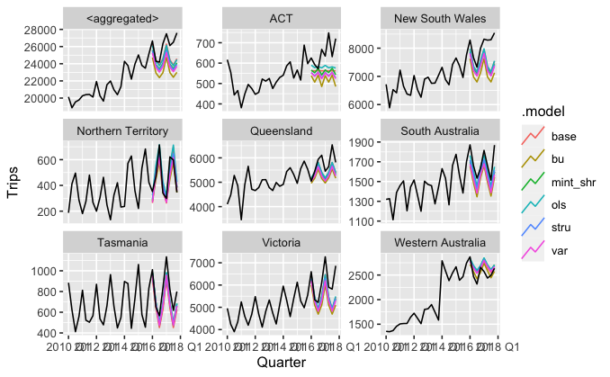

```r
fore |>
  filter(is_aggregated(Region), is_aggregated(Purpose)) |>
  autoplot(
    tourism_full |> filter(year(Quarter) >= 2010),
    level = NULL) +
  facet_wrap(vars(State), scales = "free_y")
```

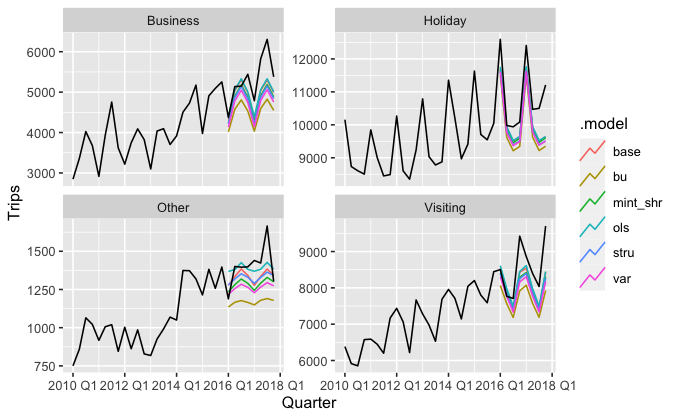

```r
fore |>
  filter(is_aggregated(State), !is_aggregated(Purpose)) |>
  autoplot(
    tourism_full |> filter(year(Quarter) >= 2010),
    level = NULL) +
  facet_wrap(vars(Purpose), scales = "free_y")
```

```r
fore |>
  filter(is_aggregated(State), is_aggregated(Purpose)) |>
  accuracy(data = tourism_full,
           measures = list(rmse = RMSE, mase = MASE)) |>
  group_by(.model) |>
  summarise(rmse = mean(rmse), mase = mean(mase))
```

| .model | rmse | mase |
| --- | --- | --- |
| base | 1720.724 | 1.532867 |
| bu | 3069.862 | 3.164072 |
| mint_shr | 2157.588 | 2.086117 |
| ols | 1803.513 | 1.627071 |
| stru | 2261.239 | 2.206438 |
| var | 2477.681 | 2.473367 |

```r
fore |>
  filter(is_aggregated(State), !is_aggregated(Purpose)) |>
  accuracy(data = tourism_full,
           measures = list(rmse = RMSE, mase = MASE)) |>
  group_by(.model) |>
  summarise(rmse = mean(rmse), mase = mean(mase))
```

| .model | rmse | mase |
| --- | --- | --- |
| base | 533.0173 | 1.329502 |
| bu | 802.2836 | 2.322806 |
| mint_shr | 586.3870 | 1.511952 |
| ols | 513.1743 | 1.250840 |
| stru | 612.9052 | 1.559908 |
| var | 661.1174 | 1.764668 |